# RBIF111 - HW5 - Midterm Exam

# 5 Question 5

## 5.1 Identify genes most positively correlated with ERBB2 in normal and cancer samples.

The code below will first obtain and divide the mRNA data into cancer and normal sample data. Then the Pearson correlation coefficient will be calculated, along with the p-value associated with the correlation. Further on, multiple hypothesis testing is utilized to control for false positives.

```r
# new variable for mRNA data
my_df3 <- mRNA_data

# separate cancer and normal data, keeping the gene column
cancer_data <- my_df3[, 1:104]
normal_data <- my_df3[, c(1, 105:207)]


### Calculate Pearson correlation & p-value

# function to calculate Pearson correlation & p-value
calc_corr <- function(df, reference_gene = "ERBB2") {
  # subset reference gene row for comparison
  ref_expression <- df %>% filter(gene == reference_gene) %>% select(-gene) %>% as.numeric()

  # make lists to store results
  cor_results <- list()

  # calculate Pearson correlation for each gene with the reference gene
  cor_results <- lapply(1:nrow(df), function(k) {
    gene_expression <- as.numeric(df[k, -1]) # Exclude gene name column
    pearson <- cor.test(gene_expression, ref_expression)

    # store gene, correlation, and p-value
    data.frame(
      gene = df$gene[k],
      Pearson_corr = pearson$estimate,
      p_value = pearson$p.value
    )
  })
  # make data frame for results
  my_corr_res <- do.call(rbind, cor_results)
  return(my_corr_res)
}

# Execute function for normal and cancer data
cancer_corr <- calc_corr(cancer_data)
normal_corr <- calc_corr(normal_data)

head(cancer_corr)
```

```
##       gene Pearson_corr   p_value
## cor   A1BG  -0.03085423 0.7570261
## cor1  A1CF   0.06266877 0.5294309
## cor2 A2BP1   0.02555641 0.7977612
## cor3 A2LD1  -0.05648534 0.5709044
## cor4 A2ML1  -0.07713001 0.4387029
## cor5   A2M  -0.01082607 0.9135714
```

```r
head(normal_corr)
```

```
##       gene Pearson_corr      p_value
## cor   A1BG    0.5814872 1.189521e-10
## cor1  A1CF    0.1672052 9.138361e-02
## cor2 A2BP1   -0.1059660 2.867334e-01
## cor3 A2LD1    0.0504286 6.129477e-01
## cor4 A2ML1    0.2526809 1.002214e-02
## cor5   A2M    0.1455077 1.425021e-01
```

Due to the large number of rows being analyzed, we increase the risk of obtaining false positives and raising the chance that some genes will appear statistically significant by chance. The *Benjamini-Hochberg* method will be used to control the false discovery rate (FDR) in this case. The method works by ranking all p-values in ascending order, then adjusting each one based on its rank and the total number of tests. This adjusts the p-value so that the probability of FDR is still within a threshold, often at 0.05.

```r
# Multiple hypothesis testing correction
cancer_corr$p_adjust <- p.adjust(cancer_corr$p_value, method = "BH")
normal_corr$p_adjust <- p.adjust(normal_corr$p_value, method = "BH")

head(cancer_corr)
```

```
##       gene Pearson_corr   p_value  p_adjust
## cor   A1BG  -0.03085423 0.7570261 0.9972943
## cor1  A1CF   0.06266877 0.5294309 0.9972943
## cor2 A2BP1   0.02555641 0.7977612 0.9972943
## cor3 A2LD1  -0.05648534 0.5709044 0.9972943
## cor4 A2ML1  -0.07713001 0.4387029 0.9972943
## cor5   A2M  -0.01082607 0.9135714 0.9972943
```

```r
head(normal_corr)
```

```
##       gene Pearson_corr      p_value     p_adjust
## cor   A1BG    0.5814872 1.189521e-10 1.116679e-09
## cor1  A1CF    0.1672052 9.138361e-02 1.277674e-01
## cor2 A2BP1   -0.1059660 2.867334e-01 3.501056e-01
## cor3 A2LD1    0.0504286 6.129477e-01 6.711923e-01
## cor4 A2ML1    0.2526809 1.002214e-02 1.705204e-02
## cor5   A2M    0.1455077 1.425021e-01 1.902612e-01
```

In a Pearson correlation analysis, a **positive** correlation between a gene and the reference gene (ERBB2) show that the mRNA expression levels of the two genes tend to increase or decrease with each other. When one gene’s expression level is high, the positively correlated gene is also likely to be high (and vice versa). Below are the top 10 positively correlated genes in reference to ERBB2, within the cancer and normal samples.

```r
# Identify top 10 correlated genes for tumor and normal
top10_cancer <- cancer_corr %>% filter(gene != "ERBB2") %>%
  arrange(desc(Pearson_corr)) %>% head(10)

top10_normal <- normal_corr %>% filter(gene != "ERBB2") %>%
  arrange(desc(Pearson_corr)) %>% head(10)

print(top10_cancer)
```

```
##              gene Pearson_corr      p_value     p_adjust
## cor17325   STARD3    0.9632904 1.704997e-59 1.700309e-55
## cor13262    PGAP3    0.9226188 1.398434e-43 9.297255e-40
## cor1978  C17orf37    0.8650002 5.145028e-32 2.565440e-28
## cor7386      GRB7    0.8457137 2.640311e-29 1.053220e-25
## cor12720   ORMDL3    0.7824848 1.669648e-22 5.550187e-19
## cor16165 SLC25A18    0.6802767 2.716972e-15 7.741430e-12
## cor19124  UGT2B10    0.6737848 6.223587e-15 1.551618e-11
## cor13664     PNMT    0.6725448 7.273867e-15 1.611970e-11
## cor7011      GJB1    0.6359847 5.267994e-13 1.050701e-09
## cor6981       GIF    0.6209934 2.598682e-12 4.711884e-09
```

```r
print(top10_normal)
```

```
##            gene Pearson_corr      p_value     p_adjust
## cor8319   IGSF9    0.8693923 1.084999e-32 1.078652e-28
## cor17194 SRCIN1    0.8437596 4.736185e-29 3.138986e-25
## cor14093  PROM2    0.8317207 1.464895e-27 7.281628e-24
## cor4966    DLG3    0.8297846 2.480251e-27 9.862966e-24
## cor5205     DSP    0.8238671 1.191165e-26 3.947321e-23
## cor3414    CDH1    0.8226364 1.638733e-26 4.654705e-23
## cor8525    IQCE    0.8204262 2.888341e-26 7.178611e-23
## cor5701   ESRP2    0.8101665 3.635477e-25 8.031577e-22
## cor14150  PRRG4    0.8092315 4.544447e-25 8.502389e-22
## cor19748 ZBTB42    0.8090866 4.703831e-25 8.502389e-22
```

For visualization of the results, below are the bar plots of the top 10 genes identified in the cancer and normal samples.

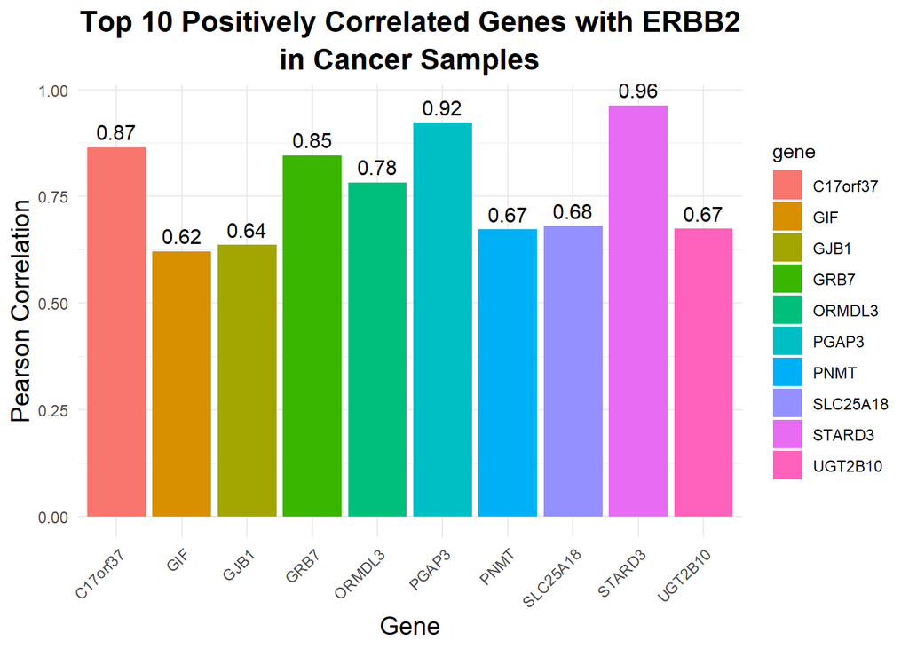

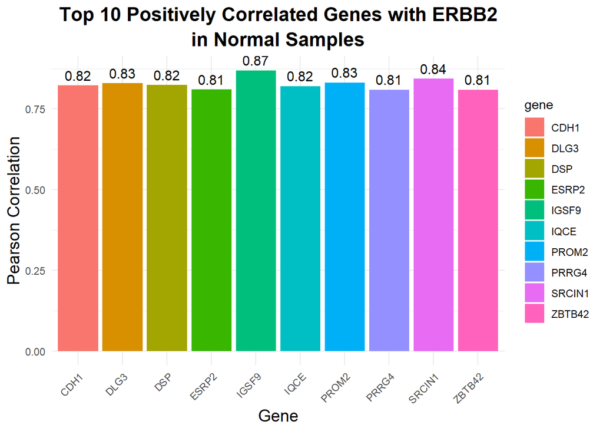